# Homework 3

Greg Werbin

## Part A

I’ll be comparing Question 5 of the 1999 and 2008 European Values Surveys – Great Britain, which has the same exact wording in both versions:

> Please look carefully at the following list of voluntary organisations and activities and say … a) which, if any, do you belong to? (Code all mentioned under (a) as ‘1’) b) which, if any, are you currently doing unpaid voluntary work for? (Code all mentioned under (b) as ‘1’)

with options:

> - Social welfare services for elderly, handicapped or deprived people
> - Religious or church organisations
> - Education, arts, music or cultural activities
> - Trade unions
> - Political parties or groups
> - Local community action on issues like poverty, employment, housing, racial equality
> - Third world development or human rights
> - Conservation, the environment, ecology, animal rights
> - Professional associations
> - Youth work (e.g. scouts, guides, youth clubs etc.)
> - Sports or recreation
> - Women’s groups
> - Peace movement
> - Voluntary organisations concerned with health
> - Other groups
> - None  
>   *(Source: p. 5 of each Field Questionnaire)*

## Part B

I’m going to graph the log-base-10 proportion of respondents who answer “yes” to each question. There will be two panels, one for each question. In each panel, I’ll draw a horizontal dot chart with the 1999 an 2008 values plotted on the same row, distinguished by the plotting character. If it helps clarity, I’ll draw straight lines to connect points from the same year. The goal is to compare the popularity of volunteer activities between 1999 and 2008. I’m using a log scale because I’m expecting that some groups will be more popular than others.

## Part C

I’ll use `ggplot2` in R, so I’ll need a data.frame that looks like:

| Category | Question | Year | Proportion |
| --- | --- | --- | --- |
| Welfare | A | 1999 | 0.15 |

## Part D

```r
library(foreign)
library(reshape2)
library(memisc)
pdt <- data.table:::print.data.table

d1999 <- read.dta("ZA3777_v3-0-1.dta")
d2008 <- read.dta("ZA4752_v1-0-0.dta")
## Checking out the structure of the file

dim(d1999)
```

```
## [1] 1000  417
```

```r
dim(d2008)
```

```
## [1] 1561  456
```

```r
head(names(d1999), 20)
```

```
##  [1] "studyno"  "version"  "id_cocas" "caseno"   "intno"    "intno2gb"
##  [7] "year"     "weight"   "v1"       "v2"       "v3"       "v4"
## [13] "v5"       "v6"       "v6a_gb"   "v7"       "v8"       "v9"
## [19] "v10"      "v11"
```

```r
head(names(d2008), 20)
```

```
##  [1] "StudyNo"  "Version"  "id_cocas" "caseno"   "intno"    "wave"
##  [7] "year"     "country"  "country1" "c_abrv"   "c_abrv1"  "weight"
## [13] "cntry_y"  "cntry1_y" "v1"       "v2"       "v3"       "v4"
## [19] "v5"       "v6"
```

```r
pdt(d1999[1:5, 1:8])
```

```
##    studyno            version     id_cocas caseno intno intno2gb year
## 1:    3777 3.0.1 (2012-12-28) 199982600001      1  2100        8 1999
## 2:    3777 3.0.1 (2012-12-28) 199982600002      2  2100        9 1999
## 3:    3777 3.0.1 (2012-12-28) 199982600003      3  2100       10 1999
## 4:    3777 3.0.1 (2012-12-28) 199982600004      4  2100        4 1999
## 5:    3777 3.0.1 (2012-12-28) 199982600005      5  2100        3 1999
##      weight
## 1: 1.647713
## 2: 1.210022
## 3: 1.585010
## 4: 1.585010
## 5: 1.294967
```

```r
pdt(d2008[1:5, 1:14])
```

```
##    StudyNo            Version     id_cocas caseno intno      wave year
## 1:    4752 1.0.0 "2010-11-30" 200882610080    397  1899 wave 2008 2009
## 2:    4752 1.0.0 "2010-11-30" 200882610093    475  3383 wave 2008 2009
## 3:    4752 1.0.0 "2010-11-30" 200882610284   1042  2410 wave 2008 2009
## 4:    4752 1.0.0 "2010-11-30" 200882611058   4401  2408 wave 2008 2009
## 5:    4752 1.0.0 "2010-11-30" 200882611516   6998  3032 wave 2008 2009
##           country       country1 c_abrv c_abrv1 weight
## 1:  Great Britain  Great Britain     GB      GB      0
## 2:  Great Britain  Great Britain     GB      GB      0
## 3:  Great Britain  Great Britain     GB      GB      0
## 4:  Great Britain  Great Britain     GB      GB      0
## 5:  Great Britain  Great Britain     GB      GB      0
##                 cntry_y                              cntry1_y
## 1: Great Britain (2009) Great Britain (2009) [with split ups]
## 2: Great Britain (2009) Great Britain (2009) [with split ups]
## 3: Great Britain (2009) Great Britain (2009) [with split ups]
## 4: Great Britain (2009) Great Britain (2009) [with split ups]
## 5: Great Britain (2009) Great Britain (2009) [with split ups]
```

```r
unique(d2008$year) # just checking, 2008/2009 difference looked suspicious
```

```
## [1] 2009
## Levels: 2008 2009
```

```r
## Saving the columns I want and dumping the rest

select <- function(...) paste0("v", unlist(lapply(as.list(sys.call())[-1], eval)))
a99 <- select(12:27)
b99 <- select(30:45)
a08 <- select(10:25)
b08 <- select(28:43)
# c(length(a99), length(b99), length(a08), length(b08))
# 16 categories

d1999 <- d1999[, c("id_cocas", "year", a99, b99)]
d2008 <- d2008[, c("id_cocas", "year", a08, b08, "f25", "f43")]
```

Variables `f25` and `f43` are for flagging inconsistencies in the 2008 survey. Unfortunately there aren’t any flags for the 1999 survey. The inconsistency codes for `f43` are:

> - Inconsistent 1: If respondent mentiones at least one organisation and “none”. if v43=1 and any of v28 to v42=1 then f43=1
> - Inconsistent 2: If respondent does not know for at least one organization whether s/he works for it and mentiones “none”. if v43=1 and none of v28 to v42=1 and any of v28 to v42=8 then f43=2
> - Inconsistent 3: If respondent does not know for at least one organization whether s/he works for it and does not mention “none”. if v43=2 and none of v28 to v42=1 and any of v28 to v42=8 then f43=3
> - Inconsistent 4: If respondent does not mention any organisation and does not mention “none”. if v43=2 and all of v28 to v42=2 then f43=4
> - Inconsistent 5: If respondent mentions at least one organization and does not know whether s/he works for “none”. if v43=8 and any of v28 to v42=1 then f43=5
> - Inconsistent 6: If respondent does not mention any organization and does not know whether s/he works for “none”. if v43=8 and all of v28 to v42=2 then f43=6
> - Inconsistent 7: If respondent mentions at least one organization and does not answer whether s/he works for “none”. if v43=9 and any of v28 to v42=1 then f43=7
> - Inconsistent 8: If respondent does not mention any organization and does not answer whether s/he works for “none”. if v43=9 and all of v28 to v42=2 then f43=8  
>   *(Source: p. 57 of the 2008 Variable Report)*

```r
knitr::kable(rbind("belong to" = table(d2008$f25),"work for" = table(d2008$f43)))
```

|  | consistent | inconsistent 1 | inconsistent 2 | inconsistent 3 | inconsistent 4 | inconsistent 5 | inconsistent 6 | inconsistent 7 | inconsistent 8 |
| --- | --- | --- | --- | --- | --- | --- | --- | --- | --- |
| belong to | 1553 | 5 | 0 | 0 | 2 | 0 | 0 | 1 | 0 |
| work for | 1553 | 1 | 0 | 0 | 7 | 0 | 0 | 0 | 0 |

There are so few inconsistent responses in the 2008 survey that in my opinion it’s not even worth deleting them. Hopefully the 1999 survey is equally clean. In principle, I should reconstruct the consistency checks and apply them to both questions in both surveys. Then I could decide what to do with each type of inconsistency and recode accordingly.

```r
reset <- function() {
  d1999 <<- read.dta("ZA3777_v3-0-1.dta")
  d2008 <<- read.dta("ZA4752_v1-0-0.dta")

  d1999 <<- d1999[, c("id_cocas", "year", a99, b99)]
  d2008 <<- d2008[, c("id_cocas", "year", a08, b08, "f25", "f43")]
}
# for fixing stuff in case I mess up

categories <- c(
  "Social welfare",
  "Religious",
  "Education, arts, music or cultural",
  "Trade unions",
  "Political",
  "Local community action",
  "Third world development or human rights",
  "Conservation, the environment, ecology, animal rights",
  "Professional associations",
  "Youth work",
  "Sports or recreation",
  "Women's groups",
  "Peace movement",
  "Organization concerned with health",
  "Other groups",
  "None"
  )
varnames <- apply(expand.grid(categories, c("A", "B")), 1, paste, collapse = "_")

names(d1999)[seq.int(3, length.out=2*16)] <- varnames

names(d2008)[seq.int(3, length.out=2*16)] <- c(varnames)
d2008$f25 <- d2008$f43 <- NULL
d2008$year <- 2008

calc_proportions <- function(x) {
  x <- as.character(x)
  x[x %nin% c("mentioned", "not mentioned")] <- NA
  x[x == "mentioned"] <- 1
  x[x == "not mentioned"] <- 0
  x <- as.numeric(x)
  mean(x, na.rm = TRUE)
}

melt_and_split <- function(DF) {
  DF <- melt(DF, id.vars = "year",
             variable.name = "category", value.name = "proportion")
  # it's not a "proportion" column yet, but it will be
  tmp <- do.call(rbind, strsplit(as.character(DF$category), "_"))
  DF[c("category", "question")] <- tmp
  DF
}

calc_melt_split <- function(DF) {
  out <- c(year = as.character(DF$year[1]), lapply(DF[-(1:2)], calc_proportions))
  out <- melt_and_split(data.frame(out, check.names = FALSE))
  out$question <- recode(out$question, "member" <- "A", "volunteer" <- "B")
  out
}

d <- rbind(calc_melt_split(d1999), calc_melt_split(d2008))
pdt(d, 5)
```

```
##     year                           category  proportion  question
##  1: 1999                     Social welfare 0.068000000    member
##  2: 1999                          Religious 0.048000000    member
##  3: 1999 Education, arts, music or cultural 0.104000000    member
##  4: 1999                       Trade unions 0.073000000    member
##  5: 1999                          Political 0.026000000    member
## ---
## 60: 2008                     Women's groups 0.011553273 volunteer
## 61: 2008                     Peace movement 0.003851091 volunteer
## 62: 2008 Organization concerned with health 0.031450578 volunteer
## 63: 2008                       Other groups 0.046885035 volunteer
## 64: 2008                               None 0.779345734 volunteer
```

## Part E

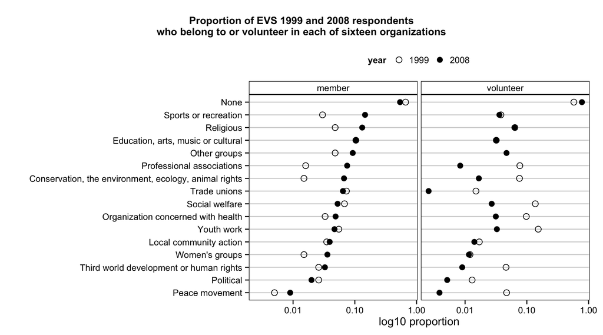

```r
library(grid)
library(ggplot2)

d$year <- factor(d$year)

ord <- order(d[d$year == "2008" & d$question == "member", "proportion"])
d$category <- factor(d$category, levels = unique(d$category)[ord])

g <- ggplot(d, aes(x = proportion, y = category)) +
  geom_point(aes(shape = year), color = NA) +
  geom_hline(aes(yintercept = as.numeric(category)), color = "lightgray") +
  geom_point(aes(shape = year), size = 3) +
  scale_x_log10() +
  scale_shape_manual(values = c(1, 16)) +
  facet_grid(~ question) +
  theme_classic() + theme(
    axis.line = element_line(color = NA),
    legend.position = "top",
    panel.border = element_rect(fill = NA),
    plot.title = element_text(size = 11, face = "bold")
    ) +
  ylab("") + xlab("log10 proportion") +
  ggtitle("Proportion of EVS 1999 and 2008 respondents\nwho belong to or volunteer in each of sixteen organizations")

## Draw the graph with the title centered properly
# from http://stackoverflow.com/a/10976398/2954547
gt <- ggplot_gtable(ggplot_build(g))
gt$layout[which(gt$layout$name == "title"), c("l", "r")] <- c(1, max(gt$layout$r))
plot.new()
grid.draw(gt)
```

## Part F, G

I think this is plenty encapsulated as-is.